# RSV (AREXVY) - Cough

OpenSourcePV

Data Lock Point: 2024_02_23

# 1 Quantitative Signal status

## 1.1 Disproportionality

The vaccine-event combination “RSV (AREXVY) - Cough” was **not a signal of disproportionate reporting** with an EB05 value of 1.02.

The threshold for being flagged as a signal of disproportionate reporting is an EB05>=2 meaning that there there is a 95% probability that the reporting of Cough was at least twice post exposure to RSV (AREXVY) than post all vaccines [1]. Under the assumption of no causality between RSV (AREXVY) and Cough and no bias it would have been expected to observe an EBGM of 1.

It means that the quantified causality criterion of strength of association is **not met**.

*It is to be noted that the nature of the spontaneous report does not provide reliable estimates of the strength of association (whatever the choice of the disproportionality method) and that some reporting bias or difference in demographic characteristics might explain the (un)observed disproportion*.

## 1.2 Time-to-onset

The vaccine-event combination “RSV (AREXVY) - Cough” was **a signal of unexpected time-to-onset distribution** with a p-value of the two-sample Kolmogorov-Smirnov test being 8.7624858^{-4} and distance between the two empirical cumulative distributions being of 24.6001059%.

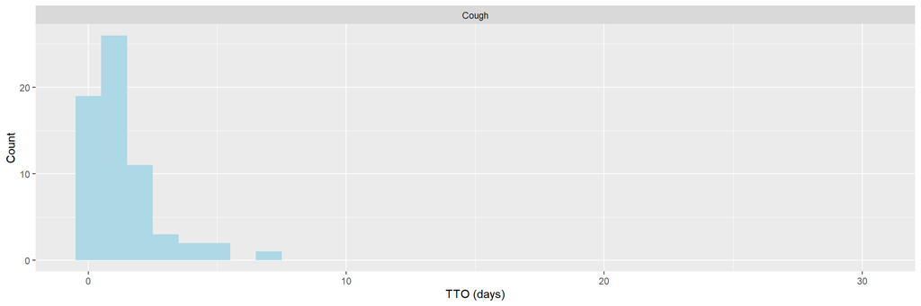

The TTO signal detection method tests if the distribution of Cough post RSV (AREXVY) is significantly different from the distribution of Cough post other vaccines using a two-sample Kolmogorov-Smirnov test [2]. The threshold for being flagged as a signal of unexpected time-to-onset distribution is a P-value <0.001 and a distance between the two empirical distributions larger than 20%. Under the assumption of no causality and no bias, it would have been expected that the time-to-onset distribution for “Cough” would have been the same post RSV (AREXVY) than post other vaccines.

It means that the quantified causality criterion of temporality is **met**.

*It is to be noted that the nature of the spontaneous report does not provide reliable estimates of the temporal relationship between the exposure and the occurrence of the events as there is the reporting bias over time: the latter the event occurs after exposure, the less chance it has to be reported. Other biases could distort the reported time-to-onset distribution (media attention, etc.)*

## 1.3 Overall

Based on the screening of the Empirical Bayes Geometric Mean (EBGM) and the screening of the time-to-onset distribution,the vaccine-event combination “RSV (AREXVY) - Cough” is **considered as quantitative signal**.

# 2 Signal History

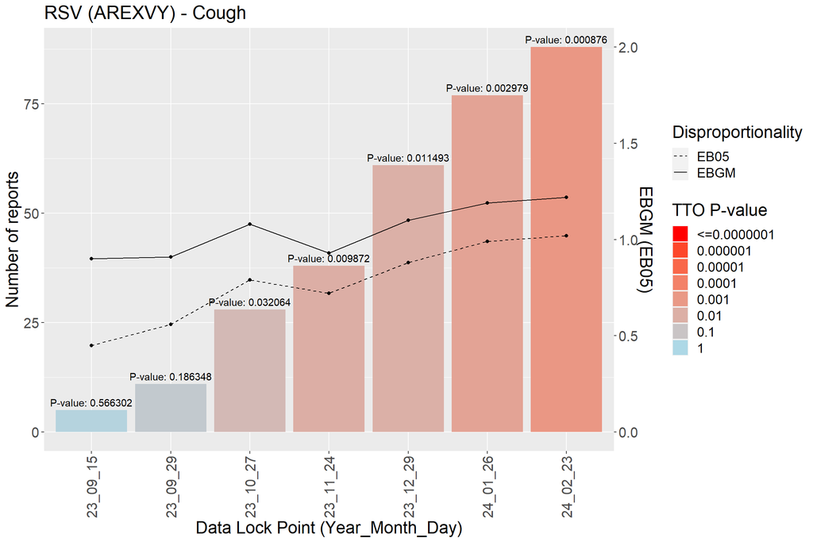

# 3 Case series

## 3.1 Characterization of the case series using vigipoint

Vigipoint [3] provides a way to pinpoint key features within the vaccine-event case series “RSV (AREXVY) - Cough” which are imbalanced (either with excess or deficit) compared to what you would expect looking at how these features are globally distributed within “RSV (AREXVY)”.

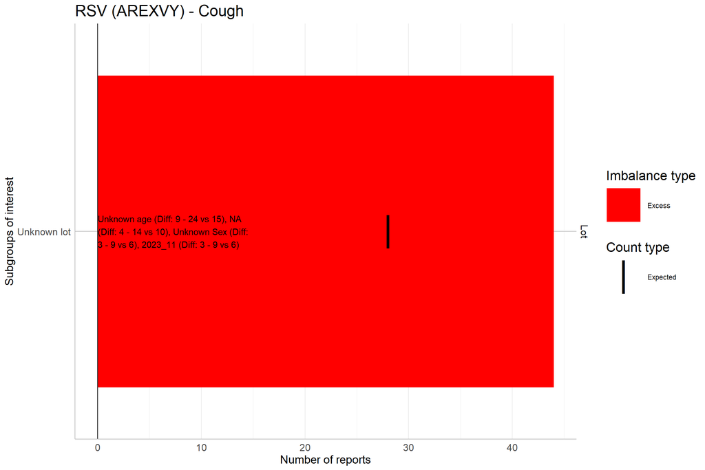

## 3.2 Seriousness

A total of 88 reports of Cough were received post exposure to RSV (AREXVY). Among them:

- 2 (2.3 %) were fatal cases.
- 0 (0.0 %) were life threatening cases.
- 3 (3.4 %) were hospitalized cases.
- 0 (0.0 %) were emergency room cases.
- 1 (1.1 %) were cases with disabilies.

11 new cases were received since last data refresh.

## 3.3 Demographic characteristics

88 cases of Cough post RSV (AREXVY) were reported in VAERS:

- Among them, there were 56 (63.6%) female cases and 22 (25%) male cases while the overall female:male ratio is 67:26%.
- The mean (median) age for patients presenting symptoms of Cough was 73 (74) years while the overall mean (median) age was 70 (71) years.
- The top 5 contributing US states for patients presenting symptoms of Cough were NA ( 20.5 %) , NY ( 9.1 %) , TX ( 8 %) , CA ( 6.8 %) , IN ( 4.5 %) while overall the top 5 of contributing US states are NA ( 13 %) , FL ( 8.8 %) , CA ( 8.3 %) , NY ( 5.8 %) , TX ( 4.3 %)